# The Evolution of Christmas Music

## Setting it up

```python
import numpy as np
import pandas as pd
import math
```

```python
!rm -f Data/christmas_songs.csv
!curl -o "Data/christmas_songs.csv" "https://hymnary.org/search?qu=topics%3AChristmas%20in%3Ainstances&limit=5809&export=csv"
```

```
  % Total    % Received % Xferd  Average Speed   Time    Time     Time  Current
                                 Dload  Upload   Total   Spent    Left  Speed
100 1554k    0 1554k    0     0  1056k      0 --:--:--  0:00:01 --:--:-- 1056k
```

```python
christmas_songs = pd.read_csv("Data/christmas_songs.csv")
christmas_songs = christmas_songs.drop_duplicates(subset=["displayTitle"])
christmas_songs.describe()
```

|  | displayTitle | firstLine | textAuthNumber | hymnalTitle | hymnalID | number | textTitle | refrainFirstLine | authors | composers | meter | tuneTitle | tuneAuthNumber | incipit | languages | textSources | tuneSources |
| --- | --- | --- | --- | --- | --- | --- | --- | --- | --- | --- | --- | --- | --- | --- | --- | --- | --- |
| count | 2762 | 2762 | 2762 | 2762 | 2762 | 2762 | 1682 | 726 | 2042 | 1979 | 1050 | 2417 | 2417 | 2261 | 2430 | 541 | 759 |
| unique | 2762 | 2330 | 1919 | 238 | 244 | 772 | 1682 | 642 | 1473 | 1401 | 283 | 1856 | 1572 | 1440 | 58 | 445 | 632 |
| top | O Christmas Tree | Hark! the herald angels sing | joy_to_the_world_the_lord_is_come | Carols Old and Carols New: for use at Christma... | COCN1916 | 23 | O Christmas Tree | Gloria in excelsis Deo | Isaac Watts | John D. Horman | Irregular | ADESTE FIDELES | stille_nacht_gruber | 565356532277115 | English | Traditional | Traditional |
| freq | 1 | 12 | 27 | 387 | 387 | 17 | 1 | 8 | 15 | 14 | 129 | 25 | 31 | 31 | 1923 | 13 | 21 |

```python
texts = pd.read_csv("Data/texts.csv")
texts.head(5)
```

|  | displayTitle | firstLine | textTitle | refrainFirstLine | textAuthNumber | languages | authors | yearsWrote | meter | textSources | totalInstances |
| --- | --- | --- | --- | --- | --- | --- | --- | --- | --- | --- | --- |
| 0 | Winters Ankunft | A, a, a, der Winter der ist da | Winters Ankunft | NaN | a_a_a_der_winter_der_ist_da | German | NaN | NaN | NaN | NaN | 6.0 |
| 1 | A Aonmhic na h'Óighe, a stór, is a sciath na m... | A Aonmhic na h'Óighe, a stór, is a sciath na m... | NaN | NaN | a_aonmhic_na_highe_a_str_is_a_sciath_na_ | NaN | NaN | NaN | NaN | NaN | 1.0 |
| 2 | A awng tangte thawhka khuiah | A awng tangte thawhka khuiah | NaN | NaN | a_awng_tangte_thawhka_khuiah | NaN | NaN | NaN | NaN | NaN | 2.0 |
| 3 | Alphabet No. 1 | A b c d e f g h i j k l m n | Alphabet No. 1 | NaN | a_b_c_d_e_f_g_h_i_j_k_l_m_n | NaN | NaN | NaN | NaN | NaN | 1.0 |
| 4 | Alphabet No. 2 | A b c d e f g h i j k l m n o P | Alphabet No. 2 | NaN | a_b_c_d_e_f_g_h_i_j_k_l_m_n_o_p | NaN | NaN | NaN | NaN | NaN | 1.0 |

### **Question 1:** What was the most featured Christmas song in hymnals?

To answer this question, we must cross reference with the "texts.csv" to find each Christmas song's popularity, measured in the total number of appearances in hymnals.

```python
merged_list = pd.merge(texts, christmas_songs, how="inner", on="displayTitle")
merged_list = merged_list.drop_duplicates(subset=["displayTitle"])
merged_list.head(20)[["displayTitle", "totalInstances"]]
```

|  | displayTitle | totalInstances |
| --- | --- | --- |
| 0 | A Babe Is Born In Bethlehem | 8.0 |
| 1 | What Tidings Bring'st Us, Messenger? | 2.0 |
| 2 | A babe lies in the cradle | 3.0 |
| 3 | A Babe Was Born, a Little One (Winter's Child) | 1.0 |
| 4 | Glory to God | 1.0 |
| 47 | 'Tis Shining Still | 5.0 |
| 48 | A Child Is Born in Bethlehem | 2.0 |
| 51 | A Great and Mighty Wonder | 107.0 |
| 52 | A King on High Is Reigning | 1.0 |
| 53 | A Little Child on the Earth | 5.0 |
| 54 | A Little Child So Fair And Bright | 3.0 |
| 55 | Ave, ave, ave Maria | 1.0 |
| 61 | A media noche resonó | 2.0 |
| 62 | A medianoche se escuchó | 1.0 |
| 63 | O come to my heart, Lord Jesus | 3.0 |
| 65 | Christmas Hymn | 1.0 |
| 76 | A Noble Theme Inspires My Heart | 1.0 |
| 77 | Come, Lord Jesus | 1.0 |
| 88 | A shepherd band their flocks are keeping | 9.0 |
| 89 | Glory to God in the highest | 1.0 |

### **Question 2:** How popular is that song?

Now, to find the most popular Christmas song, we just have to order the list by totalInstances!

```python
merged_list = merged_list.sort_values(by=["totalInstances"], ascending=False)
maxInstances = merged_list.head(1)[["totalInstances"]]
merged_list.head(10)[["displayTitle", "totalInstances"]]
```

|  | displayTitle | totalInstances |
| --- | --- | --- |
| 241 | All Hail the Power of Jesus' Name | 3374.0 |
| 1260 | Joy to the World | 1844.0 |
| 1031 | Hark! The Herald Angels Sing | 1316.0 |
| 1964 | While shepherds watched their flocks | 1088.0 |
| 516 | Brightest and Best of the Sons of the Morning | 909.0 |
| 1821 | There's a Wideness in God's Mercy | 894.0 |
| 1217 | It Came Upon the Midnight Clear | 860.0 |
| 1901 | Watchman, Tell Us of the Night | 859.0 |
| 989 | Hail to the Lord's Anointed | 841.0 |
| 1509 | O little town of Bethlehem | 828.0 |

### **Question 3:** How can we model the popularity of Christmas songs?

To find an appropriate model for the popularity of Christmas songs, it would be wise to first plot the number of instances for each song.

In order to plot this, we will be using Matplotlib. In the following block of code, we convert the merged list of Christmas songs into a NumPy array, and plot it as a histogram. For this example, I decided to use bins of width 2 for asthetic purposes. I also limited the x-axis to have a max of 50, preventing any outliers from making the graph to small to see.

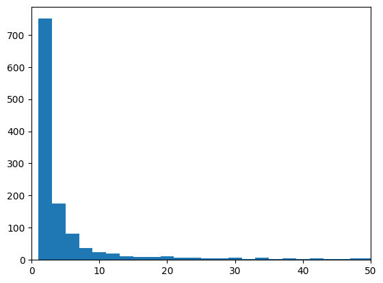

```python
import matplotlib.pyplot as plt

counts = merged_list["totalInstances"].to_numpy()
bins=np.arange(min(counts), max(counts) + 2, 2)
plt.hist(counts, bins=bins)
plt.xlim((0, 50))
plt.show()
```

Now that we can see how frequent each "totalInstances" attribute is, it is apparent that it closely follows the [Pareto distribution](https://en.wikipedia.org/wiki/Pareto_distribution)! This distribution is very common in economics and many other fields (see ["Occurence and Applications"](https://en.wikipedia.org/wiki/Pareto_distribution#Occurrence_and_applications)).

After tweaking some constants to make the distribution fit our data, we can plot the Pareto distribution overtop our histogram. In this case, we can simply use Matplotlib's plot() function, passing an array of x values and an array of y values according to the distribution's formula.

```
10
```

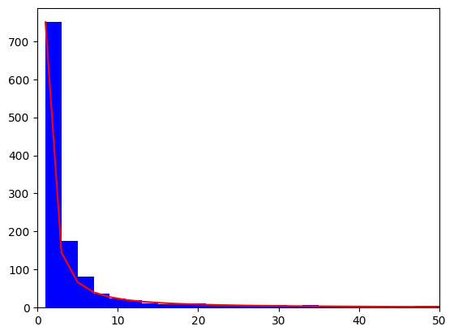

```python
x = np.arange(1, 51, 1)
count, new_bins, _ = plt.hist(counts, bins=bins, color='b')

a = 0.5 # distribution shape
m = 10 # distribution scale
print(m)
y_scalar = 750/(a*m**a)
plt.plot(bins, y_scalar*(a*m**a / bins**(a+1)), color='r')
plt.xlim((0, 50))
plt.show()
```

### **Question 4**: How does that song compare to others in popularity?

```python
percentile = 1-(m/maxInstances)**a
percentile
```

|  | totalInstances |
| --- | --- |
| 241 | 0.945559 |

### **Question 5:** How has that song's popularity changed since it's writing?

To determine how the popularity of the song has changed, we will obtain a list of all the hymnals contained in the dataset and a list of all hymnals that include this song. Next, we will plot what percentage of hymnals included the song in a certain period of time.

```python
!rm -f Data/hymnals_with_popular_song.csv
!curl -o "Data/hymnals_with_popular_song.csv" "https://hymnary.org/search?qu=in%3Ainstances%20textAuthNumber%3A%22%5Eall_hail_the_power_of_jesus_name_let%24%22&limit=4000&export=csv"
```

```
  % Total    % Received % Xferd  Average Speed   Time    Time     Time  Current
                                 Dload  Upload   Total   Spent    Left  Speed
100  909k    0  909k    0     0   525k      0 --:--:--  0:00:01 --:--:--  525k
```

Similar to how we've done before, the csv file obtained from the hymnary API is loaded into a Pandas DataFrame.

```python
hymnals_with_popular_song = pd.read_csv("Data/hymnals_with_popular_song.csv")
hymnals_with_popular_song.describe()
```

|  | displayTitle | firstLine | textAuthNumber | hymnalTitle | hymnalID | number | textTitle | refrainFirstLine | authors | composers | meter | tuneTitle | tuneAuthNumber | incipit | languages | textSources | tuneSources |
| --- | --- | --- | --- | --- | --- | --- | --- | --- | --- | --- | --- | --- | --- | --- | --- | --- | --- |
| count | 3363 | 3363 | 3363 | 3363 | 3363 | 3363 | 1156 | 354 | 2757 | 1402 | 249 | 1579 | 1579 | 1573 | 2247 | 27 | 25 |
| unique | 155 | 75 | 1 | 2699 | 2824 | 829 | 88 | 57 | 109 | 148 | 10 | 69 | 69 | 74 | 6 | 20 | 16 |
| top | All hail the power of Jesus' name, Let angels ... | All hail the power of Jesus' name, Let angels ... | all_hail_the_power_of_jesus_name_let | Hymns of the Christian Life | SCW1898 | d3 | All Hail the Power of Jesus' Name | And crown him Lord of all | John Rippon; Edward Perronet | Oliver Holden | 8.6.8.6 | CORONATION | coronation_holden | 511332123213212 | English | Rippon's Selec. | <cite>Union Harmony</cite>, 1793 |
| freq | 1117 | 1283 | 3363 | 7 | 5 | 186 | 417 | 141 | 1287 | 581 | 159 | 643 | 940 | 934 | 2240 | 2 | 5 |

```python
hymnals_with_popular_song.drop_duplicates(subset=["hymnalID"])
hymnals_with_popular_song["hymnalID"].count()
```

```
3363
```

```python
all_hymnals = pd.read_csv("Data/hymnals.csv")
all_hymnals.drop_duplicates(subset=["hymnalID"])
```

|  | hymnalID | hymnalTitle | editors | publisher | publicationPlace | publicationDate | denominations | tags |
| --- | --- | --- | --- | --- | --- | --- | --- | --- |
| 0 | 1HFS1893 | One Hundred Favorite Songs of the Salvation Army | Booth-Tucker | NaN | NaN | 1893.0 | Salvation Army | NaN |
| 1 | 1HHY1906 | One Hundred Hymns You Ought to Know | Henry F. Cope | Fleming H. Revell Company | Chicago, New York, Toronto, London, Edingburgh | 1906.0 | NaN | NaN |
| 2 | 1HNS1886 | One Hundred Non-Sectarian Hymns for Use in Chu... | A. J. Davis | G. Schirmer | New York, N.Y. | 1886.0 | NaN | NaN |
| 3 | 1HPH1860 | One Hundred Progressive Hymns | NaN | Henry B. Ashmead | Philadelphia | 1860.0 | NaN | NaN |
| 4 | 1HSG1883 | One Hundred Select Gospel Hymns from Gospel Hy... | I. D. Sankey | Biglow & Main Co. | Chicago, Ill. | 1883.0 | NaN | NaN |
| ... | ... | ... | ... | ... | ... | ... | ... | ... |
| 6694 | ZSSS1885 | The Zion Songster Nos. 1 and 2 Combined: for S... | Aldine S. Kieffer | Ruebush Kieffer & Co. | Dayton, Va. | 1887.0 | NaN | Has Music |
| 6695 | ZSSS1887 | The Zion Songster No. 2: for Sabbath School | Aldine S. Kieffer | Ruebush Kieffer & Co. | Dayton, Va. | 1887.0 | NaN | Has Music |
| 6696 | ZW1890 | Zionward: Hymns of the pilgrim life | NaN | James Nisbet & Co. | London | 1890.0 | NaN | NaN |
| 6697 | ZWHW1739 | Zionitischer Weyrauchs Huegel; oder, Weyrrhen ... | NaN | Christoph Sauer | Germantown, Penn. | 1739.0 | Seventh-Day (German) Baptists, 1728- (Ephrata ... | NaN |
| 6698 | ZZ5A1919 | Zionslieder fuer alle christlichen Zusammenkue... | International Bible Students Association | Internat'len Vereinigung Ernster Bibelfo. | New York, N.Y. | 1919.0 | International Bible Students Association | NaN |

6699 rows × 8 columns

```python
all_hymnals = all_hymnals.sort_values(by=["publicationDate"])
```

To plot the song's popularity over time, we will first make a 2d array with the year each hymnal was published and whether or not it includes the most popular Christmas song.

```python
import math
array_to_plot = np.empty((0,2))
for i in range(0, all_hymnals["hymnalID"].count()):
    year = all_hymnals.iloc[i]["publicationDate"]
    if year == 0 or math.isnan(year):
        continue
    contains_song = False
    if hymnals_with_popular_song["hymnalID"].str.contains(all_hymnals.iloc[i]["hymnalID"]).any():
        contains_song = True
    array_to_plot = np.vstack([array_to_plot, [year, contains_song]])
array_to_plot
```

```
array([[1.640e+03, 0.000e+00],
       [1.730e+03, 0.000e+00],
       [1.732e+03, 0.000e+00],
       ...,
       [2.022e+03, 0.000e+00],
       [2.023e+03, 0.000e+00],
       [2.023e+03, 1.000e+00]])
```

```python
bins = np.arange(1640, 2024+20, 20)
bins
```

```
array([1640, 1660, 1680, 1700, 1720, 1740, 1760, 1780, 1800, 1820, 1840,
       1860, 1880, 1900, 1920, 1940, 1960, 1980, 2000, 2020, 2040])
```

Next, we get the total number of hymnals per period of time and the number of hymnals with the most popular Christmas song. To make things easy, we plot histograms for each one, storing their counts. With these counts we then calculate the proportion of hymnals per 20 years that contain the song.

```
array([0.        , 0.        , 0.        , 0.        , 0.        ,
       0.        , 0.        , 0.11392405, 0.25280899, 0.29824561,
       0.43415638, 0.47684606, 0.55649241, 0.55050901, 0.61794501,
       0.27817404, 0.24096386, 0.22857143, 0.2027972 , 0.10344828])
```

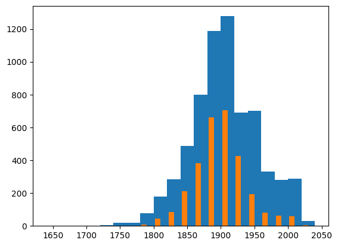

```python
total_counts, _, _ = plt.hist(array_to_plot[:,0], bins=bins)
counts, _, _ =  plt.hist(array_to_plot[array_to_plot[:,1]==1], bins=bins)

counts = counts[0]
proportions = np.zeros((len(counts)))
for i in range(len(counts)):
    if total_counts[i] == 0:
        proportions[i] = 0
    else:
        proportions[i] = counts[i] / total_counts[i]
proportions
```

Finally, we can plot the proportion over time!

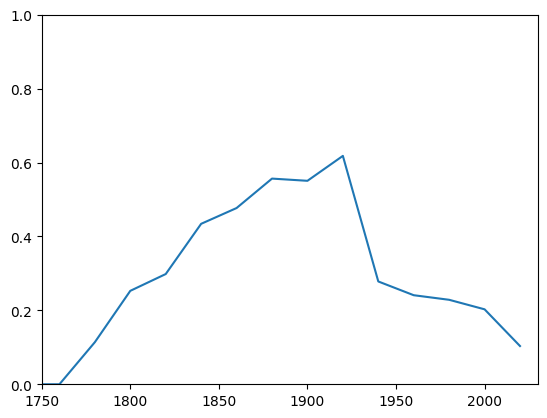

```
(array([0.        , 0.        , 0.        , 0.        , 0.        ,
        0.        , 0.        , 0.11392405, 0.25280899, 0.29824561,
        0.43415638, 0.47684606, 0.55649241, 0.55050901, 0.61794501,
        0.27817404, 0.24096386, 0.22857143, 0.2027972 , 0.10344828]),
 array([1640, 1660, 1680, 1700, 1720, 1740, 1760, 1780, 1800, 1820, 1840,
        1860, 1880, 1900, 1920, 1940, 1960, 1980, 2000, 2020, 2040]))
```

```python
plt.plot(bins[:-1], proportions)
plt.xlim((1750,2030))
plt.ylim((0.,1.))
plt.show()
proportions, bins
```

### **Question 6:** Does the song's popularity trend match the trend of number of hymnals produced?

A simple way to find out visually is to overlay the the proportion graph on top of the graph of Hymnals produced

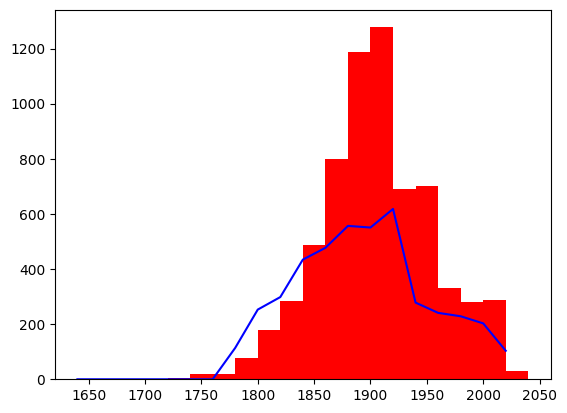

```python
plt.hist(array_to_plot[:,0], bins=bins, color='r')
proportion_scalar = 1000
plt.plot(bins[:-1], proportion_scalar * proportions, color='b')
plt.show()
```

This might be interesting to see, but it's **not** scientific! To find an answer to our question based on data, we can make a scatter plot and find the correlation between the two variables.

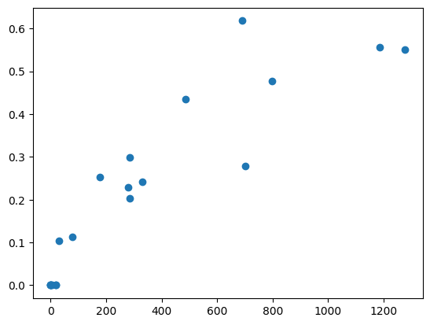

```python
plt.scatter(total_counts, proportions)
plt.show()
```

Then, to find the correlation between the two variables, we use the [Pearson Correlation Formula](https://en.wikipedia.org/wiki/Pearson_correlation_coefficient).

```python
x_mean = np.mean(total_counts)
y_mean = np.mean(proportions)


numerator = np.sum((total_counts-x_mean)*(proportions-y_mean))

sd_x = (np.sum((total_counts-x_mean)**2))**(0.5)
sd_y = (np.sum((proportions-y_mean)**2))**(0.5)

correlation = numerator/(sd_x*sd_y)
correlation
```

```
0.9038533884978152
```

Woah! That's a very strong correlation! To finish everything off, let's fit a linear regression line to the graph.

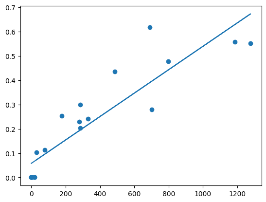

```python
from sklearn.linear_model import LinearRegression

X = np.array(total_counts[:,np.newaxis])
Y = np.array(proportions)

regression_model = LinearRegression()
regression_model.fit(X, Y)

plt.plot(X, regression_model.predict(X))
plt.scatter(total_counts, proportions)
plt.show()
```

And there we go! We've found the correlation between the number of hymnals published and the prevalence of the most popular Christmas song in hymnals! Using Python's data science libraries we've answered:

1. What was the most featured Christmas song in hymnals?
2. How popular is that song?
3. How can we model the popularity of Christmas songs?
4. How does that song compare to others in popularity?
5. How has that song's popularity changed since it's writing?
6. Does the song's popularity trend match the trend of number of hymnals produced?